# ISLR Chapter 3 with Tidymodel

The linear regression Boston housing prices lab in Chapter 3 of ISLR is rewritten here to take advantage of preferred libraries and coding patterns, specifically [Tidyverse](https://r4ds.had.co.nz/) and [Tidymodels](https://www.tmwr.org/). Also, the [attach](https://www.r-bloggers.com/2011/05/to-attach-or-not-attach-that-is-the-question/) function is best avoided in production code. You can find an R script in my github folder for ISLR.

We use Boston housing data from the ISLR2 package and predict the median value of homes (medv).

```r
library(ISLR2)
library(tidyverse)
library(tidymodels)
library(GGally)

?Boston # to see the data dictionary for Boston housing prices data, copied below
glimpse(Boston)
```

[output not shown]

Boston

A data frame with 506 rows and 13 variables.

- crim
  - per capita crime rate by town.
- zn
  - proportion of residential land zoned for lots over 25,000 sq.ft.
- indus
  - proportion of non-retail business acres per town.
- chas
  - Charles River dummy variable (= 1 if tract bounds river; 0 otherwise).
- nox
  - nitrogen oxides concentration (parts per 10 million).
- rm
  - average number of rooms per dwelling.
- age
  - proportion of owner-occupied units built prior to 1940.
- dis
  - weighted mean of distances to five Boston employment centres.
- rad
  - index of accessibility to radial highways.
- tax
  - full-value property-tax rate per $10,000.
- ptratio
  - pupil-teacher ratio by town.
- lstat
  - lower status of the population (percent).
- medv
  - median value of owner-occupied homes in $1000s.

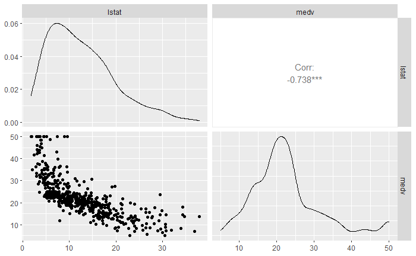

```r
Boston %>%
  select(lstat, medv) %>%
  ggpairs()
```